# Previsão de Câncer de mama

#### **Sobre:**

O câncer de mama, é atualmente um dos tipos de câncer mais mortais. Iremos investigar a utilidade da aprendizagem de máquina para detecção de tumores malignos ou benignos, aplicando técnicas de machine learning e data science utilizando do repositório de Machine Learning da UCI

http://archive.ics.uci.edu/ml/machine-learning-databases/breast-cancer-wisconsin/wdbc.names

Os dados presentes no datase tratam-se de dados reais.

#### **Diretório de trabalho:**

```r
setwd('E:/projetos/previsao_cancer_de_mama')
```

#### **Librarys:**

```r
pacman::p_load(tidyverse,class,caTools,gmodels,DMwR,caret,e1071,knitr)
```

#### **Dataset:**

```r
df <- read.csv("dataset.csv")
glimpse(df)
```

```
## Rows: 569
## Columns: 32
## $ id                <int> 87139402, 8910251, 905520, 868871, 9012568, 90653...
## $ diagnosis         <chr> "B", "B", "B", "B", "B", "B", "B", "M", "B", "B",...
## $ radius_mean       <dbl> 12.32, 10.60, 11.04, 11.28, 15.19, 11.57, 11.51, ...
## $ texture_mean      <dbl> 12.39, 18.95, 16.83, 13.39, 13.21, 19.04, 23.93, ...
## $ perimeter_mean    <dbl> 78.85, 69.28, 70.92, 73.00, 97.65, 74.20, 74.52, ...
## $ area_mean         <dbl> 464.1, 346.4, 373.2, 384.8, 711.8, 409.7, 403.5, ...
## $ smoothness_mean   <dbl> 0.10280, 0.09688, 0.10770, 0.11640, 0.07963, 0.08...
## $ compactness_mean  <dbl> 0.06981, 0.11470, 0.07804, 0.11360, 0.06934, 0.07...
## $ concavity_mean    <dbl> 0.039870, 0.063870, 0.030460, 0.046350, 0.033930,...
## $ points_mean       <dbl> 0.037000, 0.026420, 0.024800, 0.047960, 0.026570,...
## $ symmetry_mean     <dbl> 0.1959, 0.1922, 0.1714, 0.1771, 0.1721, 0.2031, 0...
## $ dimension_mean    <dbl> 0.05955, 0.06491, 0.06340, 0.06072, 0.05544, 0.06...
## $ radius_se         <dbl> 0.2360, 0.4505, 0.1967, 0.3384, 0.1783, 0.2864, 0...
```

[output cut: 19 more lines]

Todos os dados do dataset são numéricos, com exceção da variável “diagnosis” cuja é um classificador que indicará se o conjunto de dados apontam para um tipo de câncer “benigno” ou “maligno”.

#### **Ajustando os dados:**

```r
df <- df %>% select(-id) %>%
  mutate(diagnosis = factor(diagnosis, levels = c("B","M"), labels = c(0,1))) %>%
  mutate_if(is.numeric,scale)
```

Neste ponto, foi realizado o ajuste no dataset.

Realizamos a padronização das variáveis numéricas com o “scale” e além disso foi transformado a variável “diagnosis” (variável target) em “fator” com atribuição das labels 0 e 1, onde 0 = benigno e 1 = maligno.

#### **Verificando a proporção:**

```r
round(prop.table(table(df$diagnosis))*100,2)
```

```
##
##     0     1
## 62.74 37.26
```

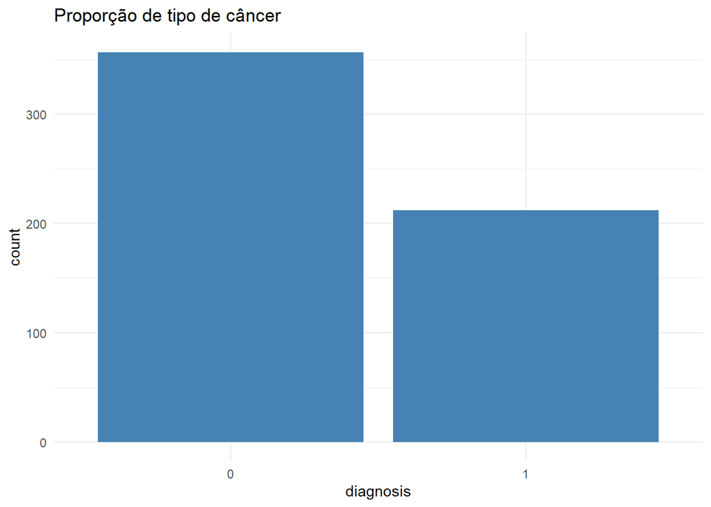

```r
ggplot(df, aes(x = diagnosis))+
  geom_bar(fill = "Steelblue")+
  labs(title = "Proporção de tipo de câncer")+
  theme_minimal()
```

Também se faz necessário verificar o balanceamento dos dados para que o modelo seja suficientemente genérico. Neste caso, há uma proporção de 62% dos dados para “Benigno” e 37% para “Maligno”. Realizaremos o balanceamento utilizando o algoritmo SMOTE.

#### **Aplicando balanceamento:**

```r
set.seed(123)
df2 <- DMwR::SMOTE(diagnosis~.,df, perc.over = 900,perc.under = 100)
round(prop.table(table(df2$diagnosis))*100,2)
```

```
##
##     0     1
## 47.37 52.63
```

#### **Dividindo dados de treino e de teste:**

```r
set.seed(123)
treino <- df2 %>% sample_frac(0.7)
teste <- df2 %>% sample_frac(0.3)
```

#### **Verificando balanceamento nos dados de treino e de teste:**

```r
set.seed(123)
round(prop.table(table(treino$diagnosis))*100,2)
```

```
##
##     0     1
## 47.77 52.23
```

```r
round(prop.table(table(teste$diagnosis))*100,2)
```

```
##
##     0     1
## 47.27 52.73
```

Utilizando ainda do mesmo princípio de balanceamento dos dados, é possível ver que o dataset de “treino e de”teste" estão balanceados.

#### **Modelo preditivo com o KNN:**

```r
set.seed(123)
ctrl <- trainControl(method = "repeatedcv", repeats = 3)
```

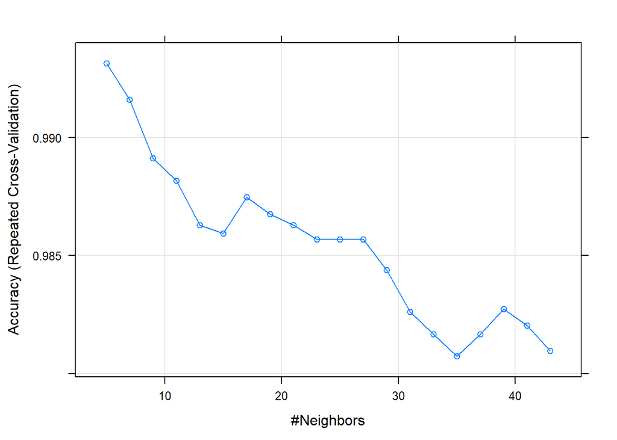

```r
set.seed(123)
knn_v1 <- caret::train(diagnosis~.,
                       data = treino,
                       method = "knn",
                       trControl = ctrl,
                       tuneLength = 20)


plot(knn_v1)
```

O plot acima mostra qual o valor de K ideal que foi utilizado.

#### **Previsões:**

```r
set.seed(123)
previsao_knn <- predict(knn_v1,newdata=teste)
confusionMatrix(previsao_knn,teste$diagnosis)
```

```
## Confusion Matrix and Statistics
##
##           Reference
## Prediction   0   1
##          0 569   0
##          1   2 637
##
##                Accuracy : 0.9983
##                  95% CI : (0.994, 0.9998)
##     No Information Rate : 0.5273
##     P-Value [Acc > NIR] : <2e-16
##
##                   Kappa : 0.9967
##
##  Mcnemar's Test P-Value : 0.4795
##
##             Sensitivity : 0.9965
##             Specificity : 1.0000
##          Pos Pred Value : 1.0000
##          Neg Pred Value : 0.9969
##              Prevalence : 0.4727
##          Detection Rate : 0.4710
##    Detection Prevalence : 0.4710
##       Balanced Accuracy : 0.9982
##
##        'Positive' Class : 0
##
```

#### **Modelo knn com métrica ROC:**

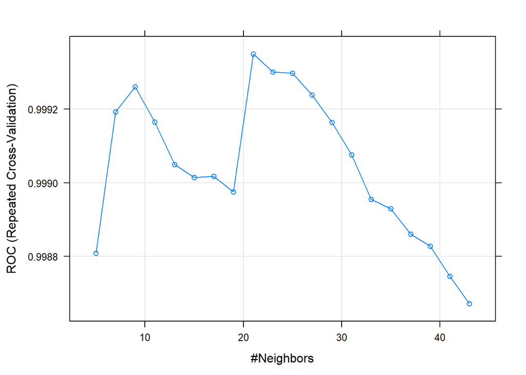

```r
set.seed(123)
controle <- trainControl(method = "repeatedcv",
                         repeats =3,
                         classProbs = TRUE,
                         summaryFunction = twoClassSummary)

df3 <- df2 %>% mutate(diagnosis = factor(diagnosis,levels = c("0","1"), labels = c("Benigno","Maligno")))
treino2 <- df3 %>%  sample_frac(0.7)
teste2 <- df3 %>% sample_frac(0.3)

knn_v2 <- caret::train(diagnosis~.,
                       data = treino2,
                       method = "knn",
                       trControl = controle,
                       metric = "ROC",
                       tuneLength = 20)

plot(knn_v2)
```

O plot acima mostra qual o valor de K ideal que foi utilizado.

#### **Previsões:**

```r
set.seed(123)
previsao_knn2 <- predict(knn_v2,teste2[-1])
confusionMatrix(previsao_knn2,teste2$diagnosis)
```

```
## Confusion Matrix and Statistics
##
##           Reference
## Prediction Benigno Maligno
##    Benigno     561       6
##    Maligno      10     631
##
##                Accuracy : 0.9868
##                  95% CI : (0.9786, 0.9924)
##     No Information Rate : 0.5273
##     P-Value [Acc > NIR] : <2e-16
##
##                   Kappa : 0.9734
##
##  Mcnemar's Test P-Value : 0.4533
##
##             Sensitivity : 0.9825
##             Specificity : 0.9906
##          Pos Pred Value : 0.9894
##          Neg Pred Value : 0.9844
##              Prevalence : 0.4727
##          Detection Rate : 0.4644
##    Detection Prevalence : 0.4694
##       Balanced Accuracy : 0.9865
##
##        'Positive' Class : Benigno
##
```

#### **Modelo preditivo com o Naive Bayes:**

```r
set.seed(123)
modelo_naive <- naiveBayes(x = treino[-1],y=treino$diagnosis)
previsao <- predict(modelo_naive,teste[-1])
conf.matrix <- table(teste[,1],previsao)
confusionMatrix(conf.matrix)
```

```
## Confusion Matrix and Statistics
##
##    previsao
##       0   1
##   0 555  16
##   1  63 574
##
##                Accuracy : 0.9346
##                  95% CI : (0.9192, 0.9479)
##     No Information Rate : 0.5116
##     P-Value [Acc > NIR] : < 2.2e-16
##
##                   Kappa : 0.8694
##
##  Mcnemar's Test P-Value : 2.274e-07
##
##             Sensitivity : 0.8981
##             Specificity : 0.9729
##          Pos Pred Value : 0.9720
##          Neg Pred Value : 0.9011
##              Prevalence : 0.5116
##          Detection Rate : 0.4594
##    Detection Prevalence : 0.4727
##       Balanced Accuracy : 0.9355
##
##        'Positive' Class : 0
##
```

#### **Modelo preditivo com regressão logística:**

```r
set.seed(123)
control <- trainControl(method = "repeatedcv", number = 10, repeats = 2)
modelo_reg_log <- train(diagnosis~., data = treino, method = "glm", trControl = control)
```

#### **Visualizando variáveis mais importantes:**

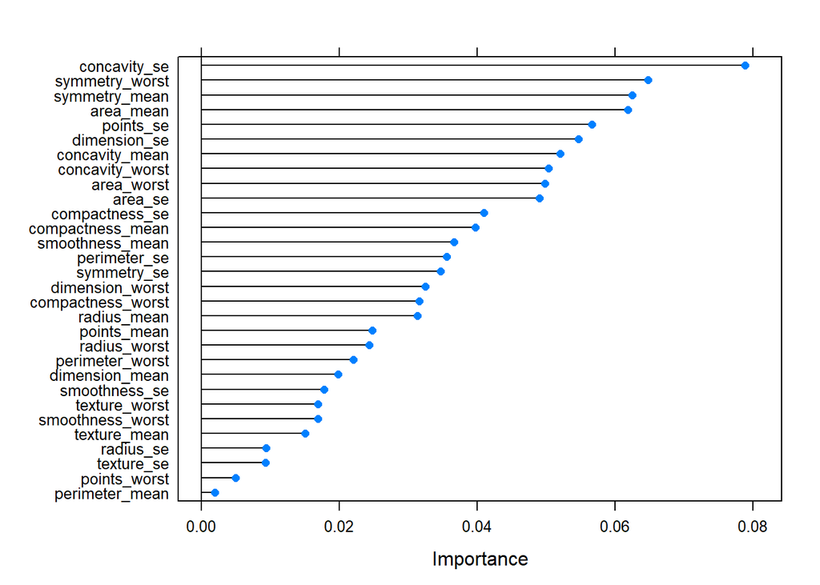

```r
set.seed(123)
importance <- varImp(modelo_reg_log, scale = FALSE);plot(importance)
```

#### **Fazendo previsões:**

```r
set.seed(123)
previsoes <- predict(modelo_reg_log, teste[-1])
```

#### **Avaliando o modelo:**

```r
set.seed(123)
confusionMatrix(table(data = previsoes, reference = teste[,1]), positive = "1")
```

```
## Confusion Matrix and Statistics
##
##     reference
## data   0   1
##    0 571   0
##    1   0 637
##
##                Accuracy : 1
##                  95% CI : (0.997, 1)
##     No Information Rate : 0.5273
##     P-Value [Acc > NIR] : < 2.2e-16
##
##                   Kappa : 1
##
##  Mcnemar's Test P-Value : NA
##
##             Sensitivity : 1.0000
##             Specificity : 1.0000
##          Pos Pred Value : 1.0000
##          Neg Pred Value : 1.0000
##              Prevalence : 0.5273
##          Detection Rate : 0.5273
##    Detection Prevalence : 0.5273
##       Balanced Accuracy : 1.0000
##
##        'Positive' Class : 1
##
```

- 100% de acurácia;
- Onde era 0 acertou 571 e errou 0;
- Onde era 1 acertou 637 e errou 0.

O Modelo com regressão logística acertou 100% dos dados, ou seja, não tivemos nenhum falso positivo e nenhum falso negativo, o que é ótimo devido ao contexto do dataset tratar de diagnóstico de câncer de mama.